# MyFirstMarkdownFile

# 1 Why are we here?

This file will demonstrate some of the features of R Markdown. Most excitingly, we will actually get to use some **real** data and *reproduce* published results.

As a reminder:

> Open research aims to transform research by making it more reproducible, transparent, reusable, collaborative, accountable, and accessible to society.

(The Turing Way Community, 2019)

## 1.1 Advantages of Open Science

Thoughts on why open and reproducible research is the future:

- It creates trust in research results
- It is the responsible thing to do with public research funding
- It is efficient
  - it saves time
  - reduces the costs of duplication
  - allows more research from the same data
- It allows knowledge transfer through fast, international, collaborative efforts
- ….

# 2 Our Analysis

## 2.1 Data

For this demonstration, we are using data from *1,500 scientists lift the lid on reproducibility* , (Baker, 2016). Check out the article [here](https://www.nature.com/news/1-500-scientists-lift-the-lid-on-reproducibility-1.19970). The data is available through [figshare](https://figshare.com/articles/Nature_Reproducibility_survey/3394951/1).

```r
# read in data
questionnaire = read.csv('Data/baker_2016_edited.txt', sep="\t")
```

Let’s get an idea at what the data looks like.

```r
knitr::kable(
  head(questionnaire[,c(1,11,28,29)]), # This is the table we will plot
  booktabs = TRUE, # We determine the formatting style as 'booktabs'
  caption = 'Data Overview, Baker 2016.') # Here we are adding a caption
```

Data Overview, Baker 2016.

| responseid | familiar_reproducibility | job | field |
| --- | --- | --- | --- |
| 24 | Fairly familiar | Research Scientist | Other |
| 27 | Very familiar | Student | Other |
| 36 | Very familiar | Associate professor/Lecturer | Other |
| 107 | Very familiar | Principal Investigator | Biology |
| 112 | Fairly familiar | PhD Student | Biology |
| 114 | Very familiar | PhD Student | Other |

Interestingly, the figures in the report we got the data from appear to use only a subset of the data: The raw data includes more research fields than the authors plot. To show that, let’s summarise the data:

```r
participants <- questionnaire %>% group_by(field) %>% summarise(count = n())
```

So here are the number of subjects per field in the raw data:

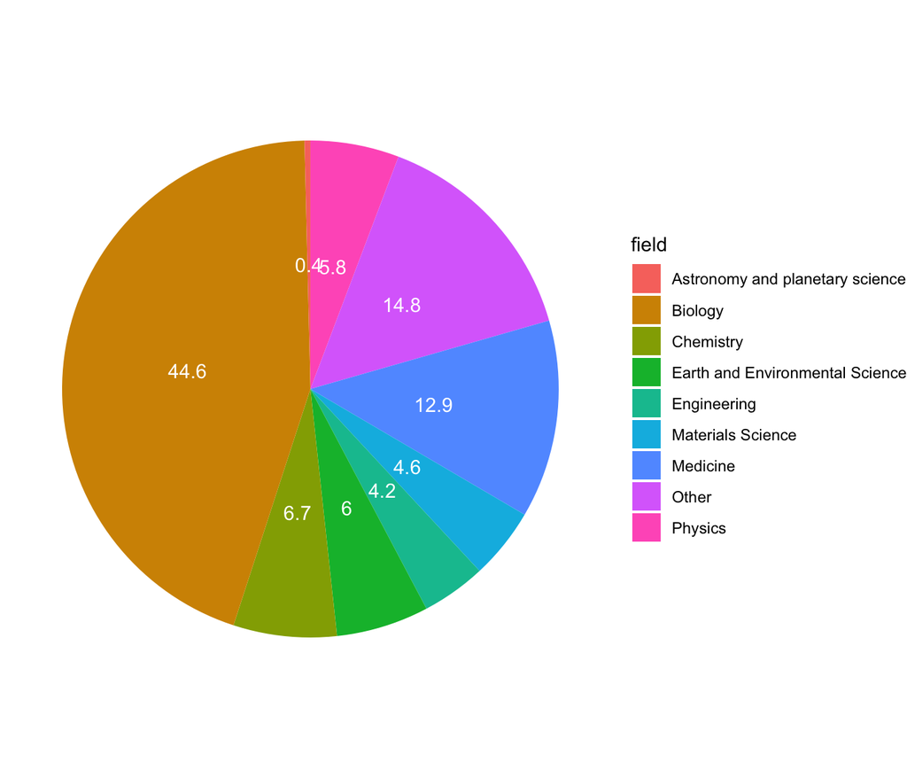

```r
participants$prop = participants$count/sum(participants$count)*100
count.data <- participants %>%
  arrange(desc(field)) %>%
  mutate(lab.ypos = cumsum(count) - 0.5*count)

ggplot(count.data, aes(x="", y=count, fill=field))+
  geom_bar(width = 1, stat = "identity")+
  coord_polar("y", start=0) +
  labs('Field')+
  geom_text(aes(y = lab.ypos, label = round(prop,1)), color = "white")+
  theme_void() +
  theme(axis.title = element_blank())
```

## 2.2 Some Figures

Now this article doesn’t only talk about open science - it also practices it! The data is freely available and under a creative commons [CC BY 4.0](https://creativecommons.org/licenses/by/4.0/) licence.

Great stuff!

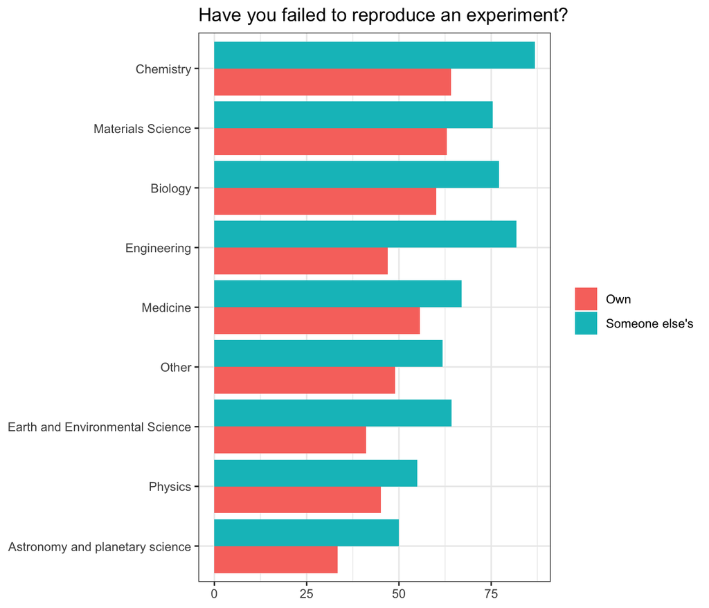

```r
ggplot(data=subset(fig3_plot_perc,response %in% 'Yes'),
       aes(x=as.factor(reorder(field,percentage)),y=percentage,fill=factor(question))) +
  geom_bar(position="dodge",stat="identity") +
  coord_flip() +
  ggtitle("Have you failed to reproduce an experiment?") +
  theme_bw()+
  theme(legend.title = element_blank(),
        axis.title = element_blank())
```

# 3 External Images

Now mostly to demonstrate how to integrate images, but also as a brief reminder of some terminology, let’s integrate an external image:

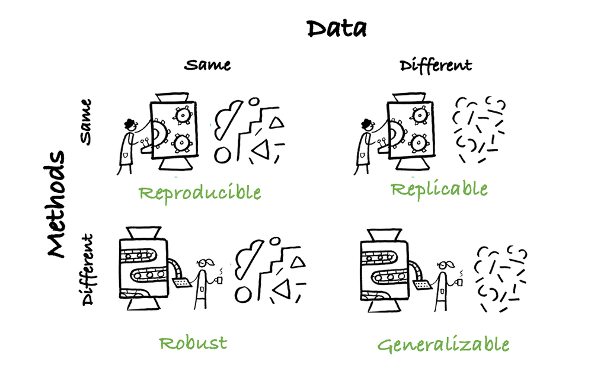

# 4 Further resources

This [cheatsheet](https://rstudio.com/wp-content/uploads/2016/03/rmarkdown-cheatsheet-2.0.pdf?_ga=2.130692559.1531018005.1610984746-1259499429.1600070494) is a great resource to have at hand when you get started.